# Tree Annotation

Guangchuang Yu School of Basic Medical Sciences, Southern Medical University

2018-11-29

# Annotate clades

ggtree (Yu et al. 2017) implements *`geom_cladelabel`* layer to annotate a selected clade with a bar indicating the clade with a corresponding label.

The *`geom_cladelabel`* layer accepts a selected internal node number. To get the internal node number, please refer to Tree Manipulation vignette.

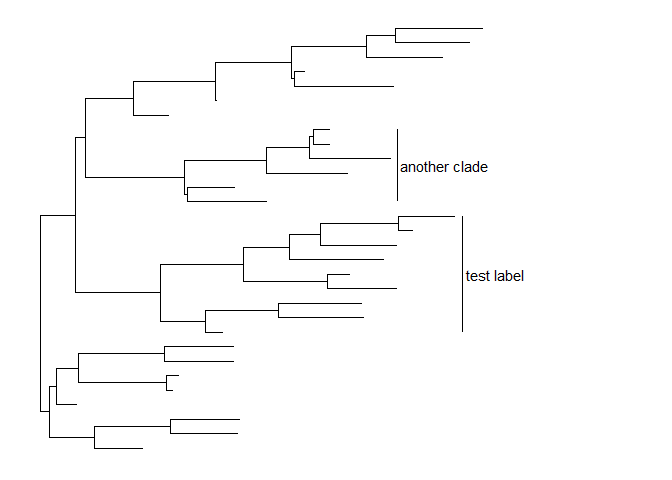

```r
set.seed(2015-12-21)
tree <- rtree(30)
p <- ggtree(tree) + xlim(NA, 6)

p + geom_cladelabel(node=45, label="test label") +
    geom_cladelabel(node=34, label="another clade")
```

Users can set the parameter, `align = TRUE`, to align the clade label, and use the parameter, `offset`, to adjust the position.

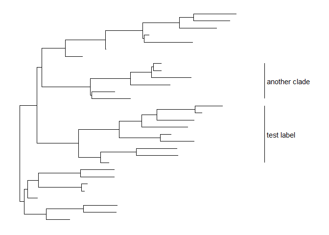

```r
p + geom_cladelabel(node=45, label="test label", align=TRUE, offset=.5) +
    geom_cladelabel(node=34, label="another clade", align=TRUE, offset=.5)
```

Users can change the color of the clade label via the parameter `color`.

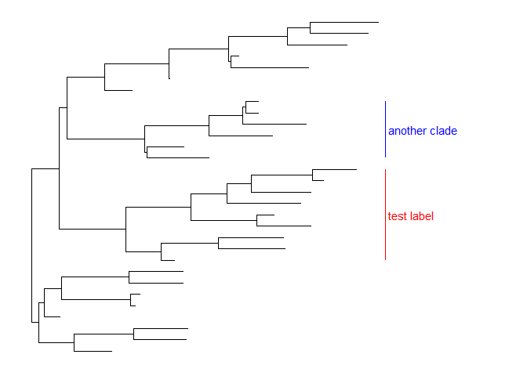

```r
p + geom_cladelabel(node=45, label="test label", align=T, color='red') +
    geom_cladelabel(node=34, label="another clade", align=T, color='blue')
```

Users can change the `angle` of the clade label text and relative position from text to bar via the parameter `offset.text`.

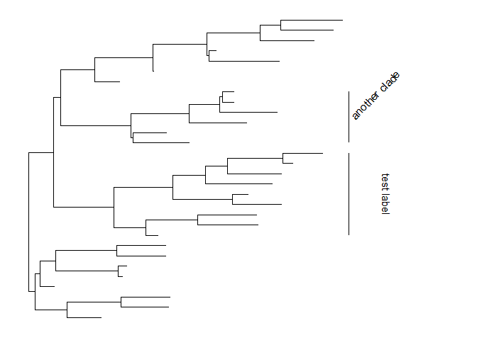

```r
p + geom_cladelabel(node=45, label="test label", align=T, angle=270, hjust='center', offset.text=.5) +
    geom_cladelabel(node=34, label="another clade", align=T, angle=45)
```

The size of the bar and text can be changed via the parameters `barsize` and `fontsize` respectively.

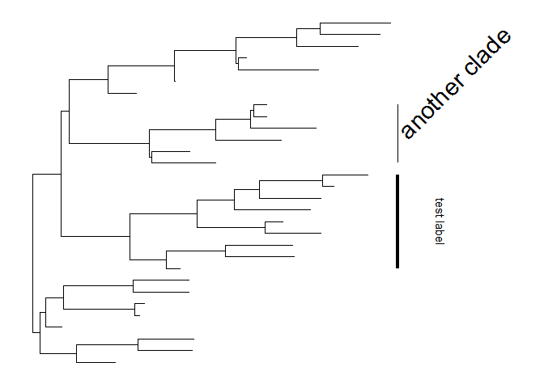

```r
p + geom_cladelabel(node=45, label="test label", align=T, angle=270, hjust='center', offset.text=.5, barsize=1.5) +
    geom_cladelabel(node=34, label="another clade", align=T, angle=45, fontsize=8)
```

Users can also use `geom_label` to label the text.

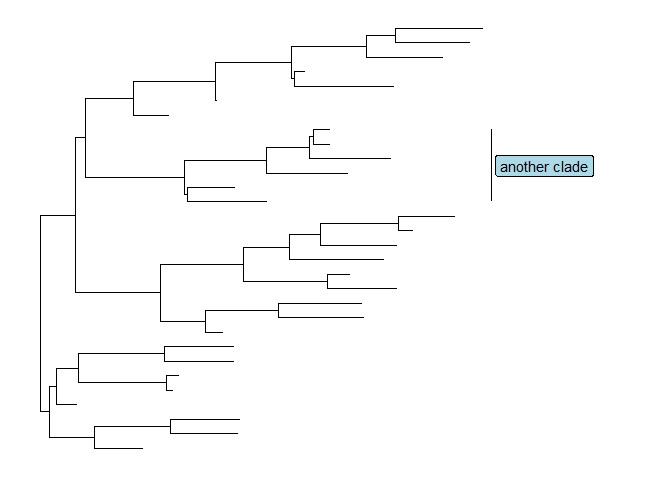

```r
p + geom_cladelabel(node=34, label="another clade", align=T, geom='label', fill='lightblue')
```

## Annotate clades for unrooted tree

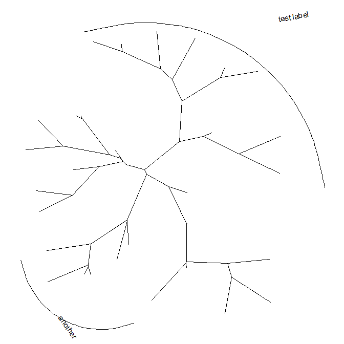

```r
pg <- ggtree(tree, layout="daylight")
pg + geom_cladelabel2(node=45, label="test label", angle=10) +
    geom_cladelabel2(node=34, label="another clade", angle=305)
```

# Labelling associated taxa (Monophyletic, Polyphyletic or Paraphyletic)

`geom_cladelabel` is designed for labelling Monophyletic (Clade) while there are related taxa that are not form a clade. `ggtree` provides `geom_strip` to add a strip/bar to indicate the association with optional label (see [the issue](https://github.com/GuangchuangYu/ggtree/issues/52)).

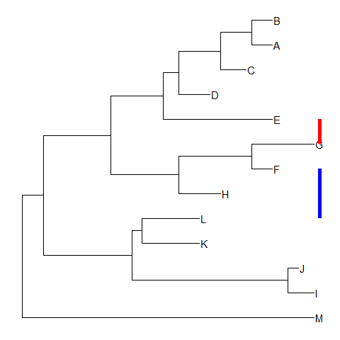

```r
nwk <- system.file("extdata", "sample.nwk", package="treeio")
tree <- read.tree(nwk)
ggtree(tree) + geom_tiplab() +
  geom_strip(5, 7, barsize=2, color='red') +
  geom_strip(6, 12, barsize=2, color='blue')
```

# Highlight clades

`ggtree` implements *`geom_hilight`* layer, that accepts an internal node number and add a layer of rectangle to highlight the selected clade.

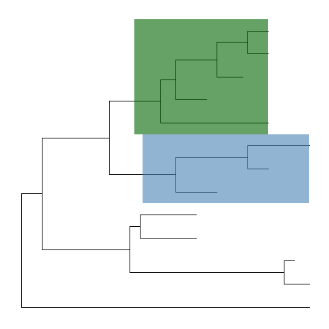

```r
ggtree(tree) + geom_hilight(node=21, fill="steelblue", alpha=.6) +
    geom_hilight(node=17, fill="darkgreen", alpha=.6)
```

[figure not shown]

```r
ggtree(tree, layout="circular") + geom_hilight(node=21, fill="steelblue", alpha=.6) +
    geom_hilight(node=23, fill="darkgreen", alpha=.6)
```

Another way to highlight selected clades is setting the clades with different colors and/or line types as demonstrated in Tree Manipulation vignette.

## Highlight balances

In addition to *`geom_hilight`*, `ggtree` also implements *`geom_balance`* which is designed to highlight neighboring subclades of a given internal node.

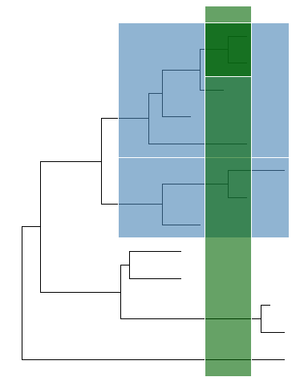

```r
ggtree(tree) +
  geom_balance(node=16, fill='steelblue', color='white', alpha=0.6, extend=1) +
  geom_balance(node=19, fill='darkgreen', color='white', alpha=0.6, extend=1)
```

## Highlight clades for unrooted tree

ggtree provides `geom_hilight_encircle` to support highlight clades for unrooted layout trees.

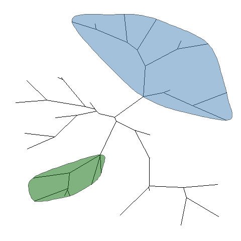

```r
pg + geom_hilight_encircle(node=45) + geom_hilight_encircle(node=34, fill='darkgreen')
```

# Taxa connection

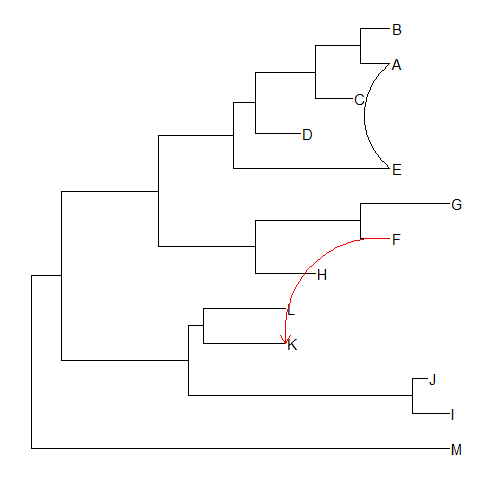

```r
ggtree(tree) + geom_tiplab() + geom_taxalink('A', 'E') +
  geom_taxalink('F', 'K', color='red', arrow=grid::arrow(length=grid::unit(0.02, "npc")))
```

# Tree annotation with output from evolution software

The treeio package implemented several parser functions to parse output from commonly used software in evolutionary biology.

Here, we used [BEAST](http://beast2.org/) (Bouckaert et al. 2014) output as an example. For details, please refer to the [Importer](https://bioconductor.org/packages/devel/bioc/vignettes/treeio/inst/doc/Importer.html) vignette.

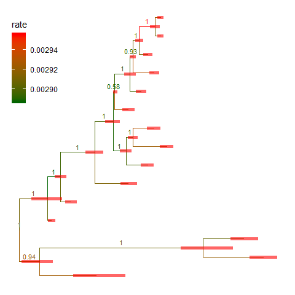

```r
file <- system.file("extdata/BEAST", "beast_mcc.tree", package="treeio")
beast <- read.beast(file)
ggtree(beast, aes(color=rate))  +
    geom_range(range='length_0.95_HPD', color='red', alpha=.6, size=2) +
    geom_nodelab(aes(x=branch, label=round(posterior, 2)), vjust=-.5, size=3) +
    scale_color_continuous(low="darkgreen", high="red") +
    theme(legend.position=c(.1, .8))
```

# Tree annotation with user specified annotation

Integrating user data to annotate phylogenetic tree can be done at different levels. The treeio package implements `full_join` methods to [combine tree data to phylogenetic tree object](https://bioconductor.org/packages/devel/bioc/vignettes/treeio/inst/doc/Importer.html). The tidytree package supports [linking tree data to phylogeny using tidyverse verbs](https://cran.r-project.org/web/packages/tidytree/vignette/tiytree.html). ggtree supports mapping external data to phylogeny for visualization and annotation on the fly.

## The `%<+%` operator

Suppose we have the following data that associate with the tree and would like to attach the data in the tree.

```r
nwk <- system.file("extdata", "sample.nwk", package="treeio")
tree <- read.tree(nwk)
p <- ggtree(tree)

dd <- data.frame(taxa = LETTERS[1:13],
                 place = c(rep("GZ", 5), rep("HK", 3), rep("CZ", 4), NA),
                 value = round(abs(rnorm(13, mean=70, sd=10)), digits=1))
## you don't need to order the data
## data was reshuffled just for demonstration
dd <- dd[sample(1:13, 13), ]
row.names(dd) <- NULL
```

```r
print(dd)
```

| taxa | place | value |
| --- | --- | --- |
| D | GZ | 78.4 |
| K | CZ | 72.7 |
| C | GZ | 83.0 |
| H | HK | 102.6 |
| E | GZ | 75.3 |
| M | NA | 67.1 |
| J | CZ | 70.4 |
| A | GZ | 51.5 |
| B | GZ | 56.6 |
| L | CZ | 79.6 |
| F | HK | 55.9 |
| I | CZ | 68.0 |
| G | HK | 86.1 |

We can imaging that the *place* column stores the location that we isolated the species and *value* column stores numerical values (*e.g.* bootstrap values).

We have demonstrated using the operator, `%<%`, to update a tree view with a new tree. Here, we will introduce another operator, `%<+%`, that attaches annotation data to a tree view. The only requirement of the input data is that its first column should be matched with the node/tip labels of the tree.

After attaching the annotation data to the tree by `%<+%`, all the columns in the data are visible to ggtree. As an example, here we attach the above annotation data to the tree view, `p`, and add a layer that showing the tip labels and colored them by the isolation site stored in *place* column.

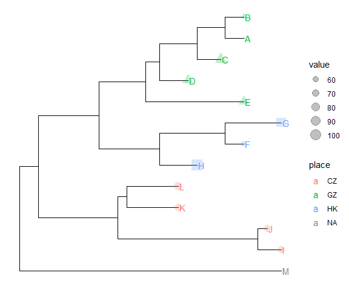

```r
p <- p %<+% dd + geom_tiplab(aes(color=place)) +
       geom_tippoint(aes(size=value, shape=place, color=place), alpha=0.25)
p + theme(legend.position="right")
```

Once the data was attached, it is always attached. So that we can add other layers to display these information easily.

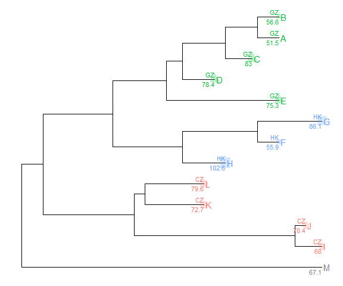

```r
p + geom_text(aes(color=place, label=place), hjust=1, vjust=-0.4, size=3) +
    geom_text(aes(color=place, label=value), hjust=1, vjust=1.4, size=3)
```

# Visualize tree with associated matrix

The `gheatmap` function is designed to visualize phylogenetic tree with heatmap of associated matrix.

In the following example, we visualized a tree of H3 influenza viruses with their associated genotype.

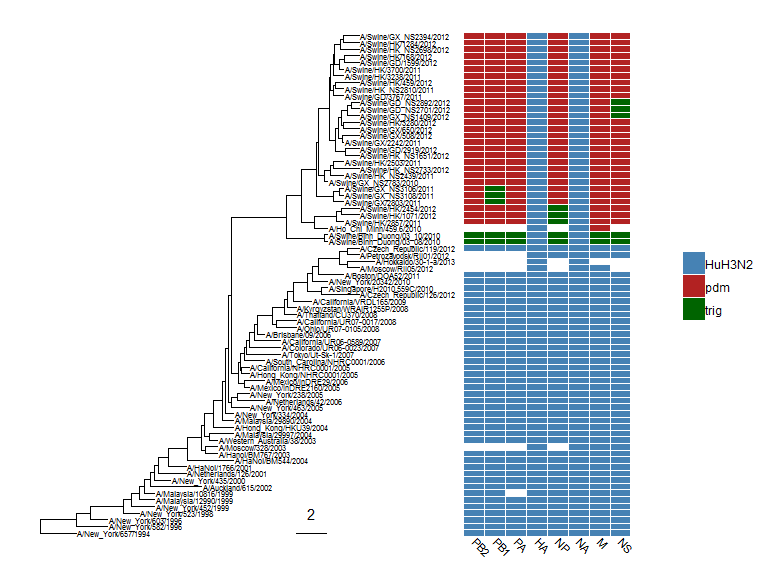

```r
beast_file <- system.file("examples/MCC_FluA_H3.tree", package="ggtree")
beast_tree <- read.beast(beast_file)

genotype_file <- system.file("examples/Genotype.txt", package="ggtree")
genotype <- read.table(genotype_file, sep="\t", stringsAsFactor=F)
colnames(genotype) <- sub("\\.$", "", colnames(genotype))
p <- ggtree(beast_tree, mrsd="2013-01-01") + geom_treescale(x=2008, y=1, offset=2)
p <- p + geom_tiplab(size=2)
gheatmap(p, genotype, offset=5, width=0.5, font.size=3, colnames_angle=-45, hjust=0) +
    scale_fill_manual(breaks=c("HuH3N2", "pdm", "trig"), values=c("steelblue", "firebrick", "darkgreen"))
```

The *width* parameter is to control the width of the heatmap. It supports another parameter *offset* for controlling the distance between the tree and the heatmap, for instance to allocate space for tip labels.

For time-scaled tree, as in this example, it’s more often to use `x` axis by using `theme_tree2`. But with this solution, the heatmap is just another layer and will change the `x` axis. To overcome this issue, we implemented `scale_x_ggtree` to set the x axis more reasonable.

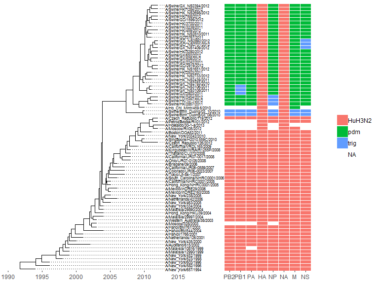

```r
p <- ggtree(beast_tree, mrsd="2013-01-01") + geom_tiplab(size=2, align=TRUE, linesize=.5) + theme_tree2()
pp <- (p + scale_y_continuous(expand=c(0, 0.3))) %>%
    gheatmap(genotype, offset=8, width=0.6, colnames=FALSE) %>%
        scale_x_ggtree()
pp + theme(legend.position="right")
```

# Visualize tree with multiple sequence alignment

With `msaplot` function, user can visualize multiple sequence alignment with phylogenetic tree, as demonstrated below:

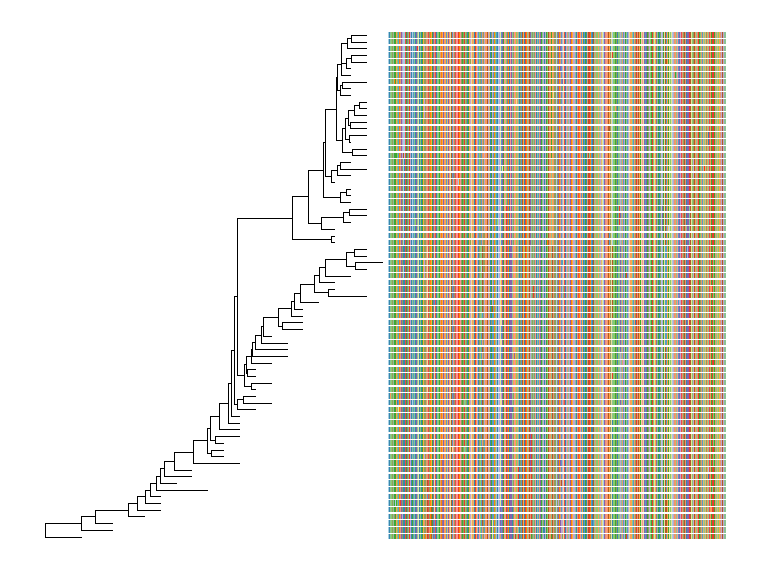

```r
fasta <- system.file("examples/FluA_H3_AA.fas", package="ggtree")
msaplot(ggtree(beast_tree), fasta)
```

A specific slice of the alignment can also be displayed by specific *window* parameter.

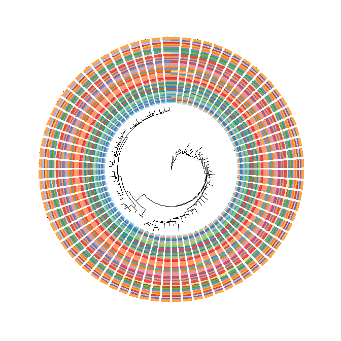

```r
msaplot(ggtree(beast_tree), fasta, window=c(150, 200)) + coord_polar(theta='y')
```

# Plot tree with associated data

For associating phylogenetic tree with different type of plot produced by user’s data, `ggtree` provides `facet_plot` function which accepts an input `data.frame` and a `geom` function to draw the input data. The data will be displayed in an additional panel of the plot.

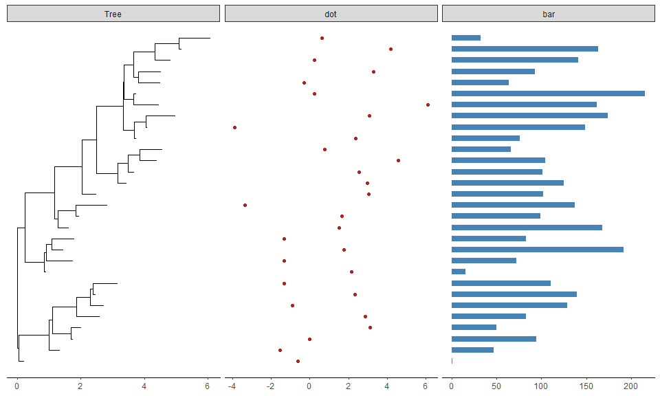

```r
tr <- rtree(30)

d1 <- data.frame(id=tr$tip.label, val=rnorm(30, sd=3))
p <- ggtree(tr)

p2 <- facet_plot(p, panel="dot", data=d1, geom=geom_point, aes(x=val), color='firebrick')
d2 <- data.frame(id=tr$tip.label, value=abs(rnorm(30, mean=100, sd=50)))

facet_plot(p2, panel='bar', data=d2, geom=geom_segment, aes(x=0, xend=value, y=y, yend=y), size=3, color='steelblue') + theme_tree2()
```

# Plot tree with images and suplots

Please refer to the following vignettes:

- [Annotating phylogenetic tree with images](https://guangchuangyu.github.io/software/ggtree/vignettes/ggtree-ggimage.html)
- [Annotate a phylogenetic tree with insets](https://guangchuangyu.github.io/software/ggtree/vignettes/ggtree-inset.html)

# References

Bouckaert, Remco, Joseph Heled, Denise Kühnert, Tim Vaughan, Chieh-Hsi Wu, Dong Xie, Marc A. Suchard, Andrew Rambaut, and Alexei J. Drummond. 2014. “BEAST 2: A Software Platform for Bayesian Evolutionary Analysis.” *PLoS Comput Biol* 10 (4):e1003537. https://doi.org/10.1371/journal.pcbi.1003537.

Yu, Guangchuang, David K. Smith, Huachen Zhu, Yi Guan, and Tommy Tsan-Yuk Lam. 2017. “Ggtree: An R Package for Visualization and Annotation of Phylogenetic Trees with Their Covariates and Other Associated Data.” *Methods in Ecology and Evolution* 8 (1):28–36. https://doi.org/10.1111/2041-210X.12628.